# 311_Service_Requests_from_2010_to_Present

# Observations 1:

[output not shown]

[figure not shown]

## to Analyze:

- Import a 311 NYC service request.
- Read or convert the columns ‘Created Date’ and Closed Date’ to datetime datatype and create a new column ‘Request_Closing_Time’ as the time elapsed between request creation and request closing. (Hint: Explore the package/module datetime)
- Provide major insights/patterns that you can offer in a visual format (graphs or tables); at least 4 major conclusions that you can come up with after generic data mining.
- Order the complaint types based on the average ‘Request_Closing_Time’, grouping them for different locations.
- Perform a statistical test for the following:

Please note: For the below statements you need to state the Null and Alternate and then provide a statistical test to accept or reject the Null Hypothesis along with the corresponding ‘p-value’.

```
Whether the average response time across complaint types is similar or not (overall)
Are the type of complaint or service requested and location related?
```

### Data Preparation & Approach

Looking at the above set of details to analyse, we need to first prep the given data

- The date fields provided in the data set are in object/string format,which needs to be formatted into correct datetime format to be able to aplply datetime functionsand compute the time elapsed between request creation and request closing
- We can use groupby methods and other aggretaion functions to summarise the data and create charts to analyse
  - Avg number of complaint by types, locations,
  - Top 5 complaint types
  - Avg time elaspsed in closing the coplaints
  - trends of complaints by Month
  - complaint composition by Types and Status
  - Summary table of complaint Types by location, showing avg closting time and avg number of complaints by type
- statistical test - Creating Null and alternate hypothese
- corelation between complaint or service requested and location

# Reading the data and parsing the date to correct format

```python
date_fields = ['Created Date', 'Closed Date', 'Due Date']

csr_df = pd.read_csv('311_Service_Requests_from_2010_to_Present.csv',parse_dates = date_fields,
                     infer_datetime_format = True)
```

```python
csr_df[['Due Date','Created Date','Closed Date']].info()
```

```
<class 'pandas.core.frame.DataFrame'>
RangeIndex: 25936 entries, 0 to 25935
Data columns (total 3 columns):
 #   Column        Non-Null Count  Dtype
---  ------        --------------  -----
 0   Due Date      25936 non-null  datetime64[ns]
 1   Created Date  25936 non-null  datetime64[ns]
 2   Closed Date   25778 non-null  datetime64[ns]
dtypes: datetime64[ns](3)
memory usage: 608.0 KB
```

```python
# we see the the three date columns are now converetd to correct date time format
```

```python
csr_df.shape
```

```
(25936, 53)
```

```python
#Droping unwanted columns for analysis
csr_df = csr_df.drop(['Taxi Company Borough','Taxi Pick Up Location','School or Citywide Complaint',
                         'Garage Lot Name','Vehicle Type','Ferry Direction','Bridge Highway Segment',
                         'Road Ramp','Bridge Highway Name','Bridge Highway Direction','Landmark',
                          'Intersection Street 2','Intersection Street 1','Cross Street 2',
                         'Cross Street 1','Facility Type','Address Type','Ferry Terminal Name',
                         'Park Facility Name','School Name','School Number','School Region',
                         'School Code','School Phone Number','School Address','School City',
                         'School State','School Zip','School Not Found'],axis=1)
```

```python
csr_df.shape
```

```
(25936, 24)
```

```python
# Total number of columns is now 24
```

```python
#Checking if any duplicate rows based on all columns
print(csr_df['Unique Key'].duplicated().unique())
print(len(csr_df))
dup_df = csr_df[csr_df.duplicated()]
dup_df
```

```
[False]
25936
```

|  | Unique Key | Created Date | Closed Date | Agency | Agency Name | Complaint Type | Descriptor | Location Type | Incident Zip | Incident Address | ... | Resolution Description | Resolution Action Updated Date | Community Board | Borough | X Coordinate (State Plane) | Y Coordinate (State Plane) | Park Borough | Latitude | Longitude | Location |
| --- | --- | --- | --- | --- | --- | --- | --- | --- | --- | --- | --- | --- | --- | --- | --- | --- | --- | --- | --- | --- | --- |

0 rows × 24 columns

## Observations 2:

# Data Preparation

```python
# adding helper column for total complaint counts
csr_df['request_count'] = 1
csr_df.head(2)
```

|  | Unique Key | Created Date | Closed Date | Agency | Agency Name | Complaint Type | Descriptor | Location Type | Incident Zip | Incident Address | ... | Resolution Action Updated Date | Community Board | Borough | X Coordinate (State Plane) | Y Coordinate (State Plane) | Park Borough | Latitude | Longitude | Location | request_count |
| --- | --- | --- | --- | --- | --- | --- | --- | --- | --- | --- | --- | --- | --- | --- | --- | --- | --- | --- | --- | --- | --- |
| 0 | 32310363 | 2015-12-31 23:59:45 | 2016-01-01 00:55:15 | NYPD | New York City Police Department | Noise - Street/Sidewalk | Loud Music/Party | Street/Sidewalk | 10034.0 | 71 VERMILYEA AVENUE | ... | 01/01/2016 12:55:15 AM | 12 MANHATTAN | MANHATTAN | 1005409.0 | 254678.0 | MANHATTAN | 40.865682 | -73.923501 | (40.86568153633767, -73.92350095571744) | 1 |
| 1 | 32309934 | 2015-12-31 23:59:44 | 2016-01-01 01:26:57 | NYPD | New York City Police Department | Blocked Driveway | No Access | Street/Sidewalk | 11105.0 | 27-07 23 AVENUE | ... | 01/01/2016 01:26:57 AM | 01 QUEENS | QUEENS | 1007766.0 | 221986.0 | QUEENS | 40.775945 | -73.915094 | (40.775945312321085, -73.91509393898605) | 1 |

2 rows × 25 columns

```python
csr_df['request_count'].sum()
```

```
25936
```

```python
# Further Droping unwanted columns which will not be used for analysis
csr_df = csr_df.drop(['Incident Address','Street Name','Y Coordinate (State Plane)',
                         'X Coordinate (State Plane)','Incident Zip','Resolution Action Updated Date'],axis=1)
```

```python
csr_df.shape
```

```
(25936, 19)
```

```python
#handling Missing values
csr_df.isnull().sum().sort_values(ascending=False)
```

```
Descriptor                381
Longitude                 223
Latitude                  223
Location                  223
City                      173
Closed Date               158
Park Borough                1
request_count               0
Created Date                0
Agency                      0
Agency Name                 0
Complaint Type              0
Status                      0
Location Type               0
Due Date                    0
Resolution Description      0
Community Board             0
Borough                     0
Unique Key                  0
dtype: int64
```

```python
csr_df.describe(include='object')
```

|  | Agency | Agency Name | Complaint Type | Descriptor | Location Type | City | Status | Resolution Description | Community Board | Borough | Park Borough | Location |
| --- | --- | --- | --- | --- | --- | --- | --- | --- | --- | --- | --- | --- |
| count | 25936 | 25936 | 25936 | 25555 | 25936 | 25763 | 25936 | 25936 | 25936 | 25936 | 25935 | 25713 |
| unique | 1 | 2 | 20 | 39 | 14 | 47 | 4 | 14 | 66 | 6 | 6 | 17069 |
| top | NYPD | New York City Police Department | Blocked Driveway | No Access | Street/Sidewalk | BROOKLYN | Closed | The Police Department responded to the complai... | 05 QUEENS | BROOKLYN | BROOKLYN | (40.83036235589997, -73.86602154214397) |
| freq | 25936 | 25935 | 8032 | 6009 | 21491 | 8824 | 25778 | 7717 | 942 | 8824 | 8823 | 154 |

## Observations 3:

- There are some nul values in closed date and those is becasue the status for thoe complaints/request is still either Open, Assigned or draft, so we will keep these closed date entries as NAN
- other NANs we will handle as we do groupby to summarise and either replace it with freq or mean ccordingly

## Q1.Read or convert the columns ‘Created Date’ and Closed Date’ to datetime datatype and create a new column ‘Request_Closing_Time’ as the time elapsed between request creation and request closing. (Hint: Explore the package/module datetime)

```python
import datetime
```

```python
# timedelat column for request create ddate and Closed date
csr_df['Request_Closing_Time'] = csr_df['Closed Date']-csr_df['Created Date']
```

```python
csr_df.head(2)
```

|  | Unique Key | Created Date | Closed Date | Agency | Agency Name | Complaint Type | Descriptor | Location Type | City | Status | Due Date | Resolution Description | Community Board | Borough | Park Borough | Latitude | Longitude | Location | request_count | Request_Closing_Time |
| --- | --- | --- | --- | --- | --- | --- | --- | --- | --- | --- | --- | --- | --- | --- | --- | --- | --- | --- | --- | --- |
| 0 | 32310363 | 2015-12-31 23:59:45 | 2016-01-01 00:55:15 | NYPD | New York City Police Department | Noise - Street/Sidewalk | Loud Music/Party | Street/Sidewalk | NEW YORK | Closed | 2016-01-01 07:59:45 | The Police Department responded and upon arriv... | 12 MANHATTAN | MANHATTAN | MANHATTAN | 40.865682 | -73.923501 | (40.86568153633767, -73.92350095571744) | 1 | 0 days 00:55:30 |
| 1 | 32309934 | 2015-12-31 23:59:44 | 2016-01-01 01:26:57 | NYPD | New York City Police Department | Blocked Driveway | No Access | Street/Sidewalk | ASTORIA | Closed | 2016-01-01 07:59:44 | The Police Department responded to the complai... | 01 QUEENS | QUEENS | QUEENS | 40.775945 | -73.915094 | (40.775945312321085, -73.91509393898605) | 1 | 0 days 01:27:13 |

```python
#mean of time delta
csr_df['Request_Closing_Time'].mean()
```

```
Timedelta('0 days 04:36:52.167158041')
```

```python
# Creating two additional columns 'Request_Closing_in_days' and 'Request_Closing_in_hrs' to maniplulate the data
# and apply aggregate functions while doing further analysis

csr_df['Request_Closing_in_days'] = (csr_df['Closed Date']-csr_df['Created Date']).dt.days
csr_df['Request_Closing_in_hrs'] = (csr_df['Closed Date']-csr_df['Created Date'])/pd.Timedelta('1 hour')
csr_df.head(2)
```

|  | Unique Key | Created Date | Closed Date | Agency | Agency Name | Complaint Type | Descriptor | Location Type | City | Status | ... | Community Board | Borough | Park Borough | Latitude | Longitude | Location | request_count | Request_Closing_Time | Request_Closing_in_days | Request_Closing_in_hrs |
| --- | --- | --- | --- | --- | --- | --- | --- | --- | --- | --- | --- | --- | --- | --- | --- | --- | --- | --- | --- | --- | --- |
| 0 | 32310363 | 2015-12-31 23:59:45 | 2016-01-01 00:55:15 | NYPD | New York City Police Department | Noise - Street/Sidewalk | Loud Music/Party | Street/Sidewalk | NEW YORK | Closed | ... | 12 MANHATTAN | MANHATTAN | MANHATTAN | 40.865682 | -73.923501 | (40.86568153633767, -73.92350095571744) | 1 | 0 days 00:55:30 | 0.0 | 0.925000 |
| 1 | 32309934 | 2015-12-31 23:59:44 | 2016-01-01 01:26:57 | NYPD | New York City Police Department | Blocked Driveway | No Access | Street/Sidewalk | ASTORIA | Closed | ... | 01 QUEENS | QUEENS | QUEENS | 40.775945 | -73.915094 | (40.775945312321085, -73.91509393898605) | 1 | 0 days 01:27:13 | 0.0 | 1.453611 |

2 rows × 22 columns

```python
csr_df.describe()
```

|  | Unique Key | Latitude | Longitude | request_count | Request_Closing_Time | Request_Closing_in_days | Request_Closing_in_hrs |
| --- | --- | --- | --- | --- | --- | --- | --- |
| count | 2.593600e+04 | 25713.000000 | 25713.000000 | 25936.0 | 25778 | 25778.000000 | 25778.000000 |
| mean | 3.222250e+07 | 40.720317 | -73.926914 | 1.0 | 0 days 04:36:52.167158041 | 0.024595 | 4.614491 |
| std | 4.894781e+04 | 0.080338 | 0.079934 | 0.0 | 0 days 08:23:39.624264960 | 0.292037 | 8.394340 |
| min | 3.213370e+07 | 40.501279 | -74.254937 | 1.0 | 0 days 00:02:51 | 0.000000 | 0.047500 |
| 25% | 3.218226e+07 | 40.663273 | -73.976665 | 1.0 | 0 days 01:18:34.250000 | 0.000000 | 1.309514 |
| 50% | 3.222184e+07 | 40.715292 | -73.932659 | 1.0 | 0 days 02:45:31 | 0.000000 | 2.758611 |
| 75% | 3.226666e+07 | 40.766758 | -73.872671 | 1.0 | 0 days 05:28:01 | 0.000000 | 5.466944 |
| max | 3.231065e+07 | 40.910452 | -73.700837 | 1.0 | 24 days 01:21:06 | 24.000000 | 577.351667 |

```python
print(f"mean of Requests_Closing_in_day is: {csr_df.Request_Closing_in_days.mean()}")
print(f"mean of Requests_Closing_in_hrs is: {csr_df.Request_Closing_in_hrs.mean()}")
```

```
mean of Requests_Closing_in_day is: 0.024594615563658932
mean of Requests_Closing_in_hrs is: 4.614490877233795
```

```python
csr_df['Request_Closing_Time'].value_counts(dropna=False).sort_values(ascending=False).head()
```

```
NaT                158
0 days 01:03:21      8
0 days 01:05:42      8
0 days 01:42:11      7
0 days 01:13:37      7
Name: Request_Closing_Time, dtype: int64
```

```python
csr_df['Request_Closing_Time'].max()
```

```
Timedelta('24 days 01:21:06')
```

```python
csr_df['Request_Closing_Time_Bin'] = pd.cut(csr_df['Request_Closing_in_hrs'], 100)
csr_df['Request_Closing_Time_Bin'].value_counts(dropna = False)
```

```
(-0.53, 5.821]        19828
(5.821, 11.594]        4111
(11.594, 17.367]        995
(17.367, 23.14]         366
(23.14, 28.913]         190
                      ...
(369.522, 375.295]        0
(375.295, 381.068]        0
(381.068, 386.841]        0
(386.841, 392.614]        0
(288.7, 294.473]          0
Name: Request_Closing_Time_Bin, Length: 101, dtype: int64
```

```python
import matplotlib.pyplot as plt
%matplotlib inline
import seaborn as sns
```

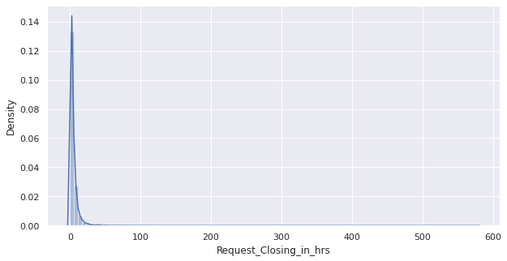

```python
f, ax = plt.subplots(figsize=(10,5))
sns.distplot(csr_df['Request_Closing_in_hrs'], bins=100)
plt.show()
```

```python
234336/len(csr_df)
```

```
9.035163479333745
```

```python
csr_df.describe()
```

|  | Unique Key | Latitude | Longitude | request_count | Request_Closing_Time | Request_Closing_in_days | Request_Closing_in_hrs |
| --- | --- | --- | --- | --- | --- | --- | --- |
| count | 2.593600e+04 | 25713.000000 | 25713.000000 | 25936.0 | 25778 | 25778.000000 | 25778.000000 |
| mean | 3.222250e+07 | 40.720317 | -73.926914 | 1.0 | 0 days 04:36:52.167158041 | 0.024595 | 4.614491 |
| std | 4.894781e+04 | 0.080338 | 0.079934 | 0.0 | 0 days 08:23:39.624264960 | 0.292037 | 8.394340 |
| min | 3.213370e+07 | 40.501279 | -74.254937 | 1.0 | 0 days 00:02:51 | 0.000000 | 0.047500 |
| 25% | 3.218226e+07 | 40.663273 | -73.976665 | 1.0 | 0 days 01:18:34.250000 | 0.000000 | 1.309514 |
| 50% | 3.222184e+07 | 40.715292 | -73.932659 | 1.0 | 0 days 02:45:31 | 0.000000 | 2.758611 |
| 75% | 3.226666e+07 | 40.766758 | -73.872671 | 1.0 | 0 days 05:28:01 | 0.000000 | 5.466944 |
| max | 3.231065e+07 | 40.910452 | -73.700837 | 1.0 | 24 days 01:21:06 | 24.000000 | 577.351667 |

## Q2 Provide major insights/patterns that you can offer in a visual format (graphs or tables); at least 4 major conclusions that you can come up with after generic data mining

```python
csr_df['Complaint Type'].isnull().sum()
```

```
0
```

```python
# finding the frequency of the words appear in the Customer Complaints Column and visualing using wordcloud
from wordcloud import WordCloud, STOPWORDS
```

```python
complaints_list= csr_df['Complaint Type']
```

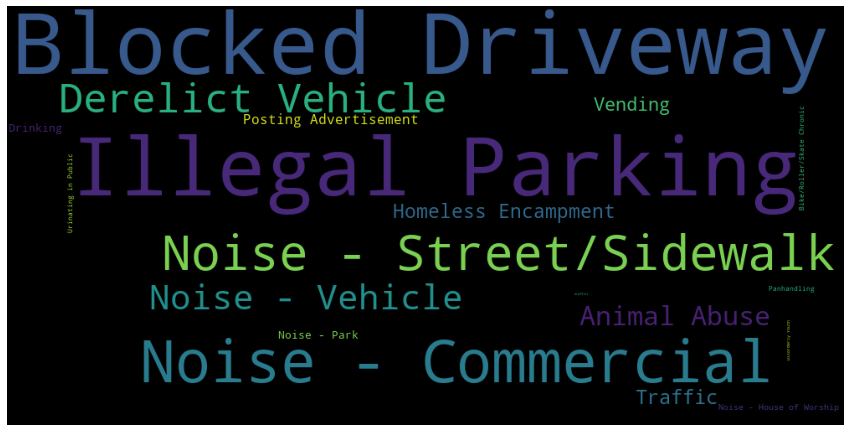

```python
from collections import Counter
word_could_dict=Counter(complaints_list)
wordcloud = WordCloud(width = 1000, height = 500).generate_from_frequencies(word_could_dict)

plt.figure(figsize=(15,8))
plt.imshow(wordcloud)
plt.axis("off")
plt.show()
```

```python
csr_df.columns
```

```
Index(['Unique Key', 'Created Date', 'Closed Date', 'Agency', 'Agency Name',
       'Complaint Type', 'Descriptor', 'Location Type', 'City', 'Status',
       'Due Date', 'Resolution Description', 'Community Board', 'Borough',
       'Park Borough', 'Latitude', 'Longitude', 'Location', 'request_count',
       'Request_Closing_Time', 'Request_Closing_in_days',
       'Request_Closing_in_hrs', 'Request_Closing_Time_Bin'],
      dtype='object')
```

```python
complaints_df=csr_df.groupby(['Complaint Type']).agg({'request_count':'sum','Request_Closing_in_days':'mean',
                                        'Request_Closing_in_hrs':'mean'}).reset_index()

complaints_df.rename(columns={'Complaint Type':'Complaint_Type',
                              'Request_Closing_in_days':'avg_Request_Closing_in_days',
                              'Request_Closing_in_hrs':'avg_Request_Closing_in_hrs'}, inplace = True)



complaints_df.sort_values('request_count', ascending=False).style.hide_index()
```

| Complaint_Type | request_count | avg_Request_Closing_in_days | avg_Request_Closing_in_hrs |
| --- | --- | --- | --- |
| Blocked Driveway | 8032 | 0.024941 | 5.093078 |
| Illegal Parking | 7388 | 0.018863 | 4.541527 |
| Noise - Commercial | 3449 | 0.010201 | 3.286885 |
| Noise - Street/Sidewalk | 2344 | 0.016429 | 3.553546 |
| Derelict Vehicle | 1567 | 0.088330 | 7.509612 |
| Noise - Vehicle | 1126 | 0.013345 | 3.724591 |
| Animal Abuse | 651 | 0.075501 | 6.397961 |
| Traffic | 330 | 0.030303 | 4.348864 |
| Homeless Encampment | 307 | 0.006515 | 4.507512 |
| Vending | 292 | 0.003425 | 3.604324 |
| Posting Advertisement | 136 | 0.000000 | 1.326305 |
| Drinking | 92 | 0.077778 | 6.280269 |
| Noise - Park | 91 | 0.021978 | 4.445650 |
| Noise - House of Worship | 45 | 0.000000 | 2.185414 |
| Bike/Roller/Skate Chronic | 26 | 0.000000 | 3.651088 |
| Panhandling | 25 | 0.000000 | 3.478922 |
| Urinating in Public | 22 | 0.000000 | 3.253826 |
| Disorderly Youth | 7 | 0.000000 | 2.140913 |
| Graffiti | 5 | 0.000000 | 4.196889 |
| Illegal Fireworks | 1 | 0.000000 | 0.316944 |

## Observations:

- Looking at the Wordcloud and the above table, Blocked Driveway and Illegal Praking are the two top most type of complaints received by NYC311

```python
# No of complaints by Location Type
df_location_Type=csr_df.groupby(['Location Type'])[['Unique Key']].count().reset_index()
df_location_Type.rename(columns={'Location Type':'Location_Type','Unique Key':'No_of_Complaints'},inplace=True)
```

```python
sns.set() # Setting seaborn as default style even if use only matplotlib
```

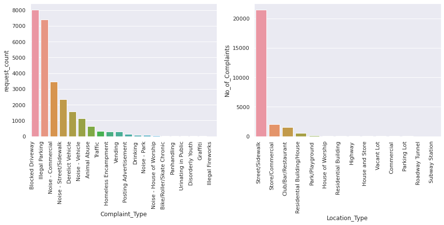

```python
fig, axs = plt.subplots(ncols=2, figsize=(15,5))

ax0=sns.barplot(x='Complaint_Type',y='request_count',data = complaints_df,
           order=complaints_df.sort_values('request_count',ascending = False).Complaint_Type,ax=axs[0])
ax0.set_xticklabels(ax0.get_xticklabels(), rotation=90, ha="right")


ax1=sns.barplot(x='Location_Type',y='No_of_Complaints',data = df_location_Type,
           order=df_location_Type.sort_values('No_of_Complaints',ascending = False).Location_Type,ax=axs[1])
ax1.set_xticklabels(ax1.get_xticklabels(), rotation=90, ha="right")

plt.show()
```

## Observations:

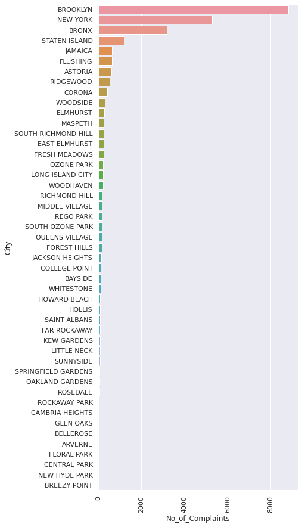

```python
df_City=csr_df.groupby(['City'])[['Unique Key']].count().reset_index()
df_City.rename(columns={'Unique Key':'No_of_Complaints'},inplace=True)
df_City
#df_3= df_3.head(10)

f, ax = plt.subplots(figsize=(6, 15))
#CT = list(df_1['Complaint Type'])
sns.barplot(y='City',x='No_of_Complaints',data = df_City,
           order=df_City.sort_values('No_of_Complaints',ascending = False).City)
plt.xticks(rotation=90)
plt.show()
```

```python
df_complaints_by_Month =csr_df[['Unique Key','Created Date','Closed Date','Status','Complaint Type','Location Type','City','Borough']]
df_complaints_by_Month['Request_Created_Month']=df_complaints_by_Month['Created Date'].dt.strftime('%b')
#df_complaints_by_Month['Request_Closed_Month']=df_complaints_by_Month['Closed Date'].dt.strftime('%b')
#df_complaints_by_Month
```

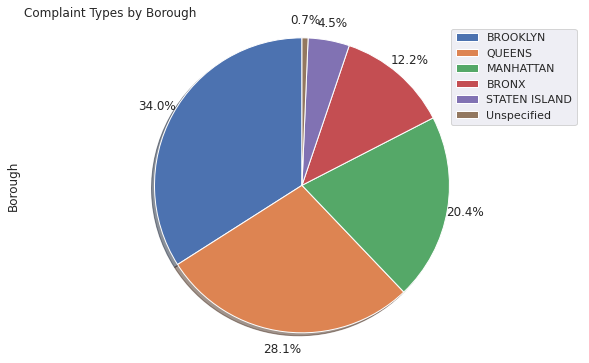

```python
#(df_complaints_by_Month['Status'].value_counts()).plot(kind='pie')

(df_complaints_by_Month['Borough'].value_counts()).plot(kind='pie',
                        figsize =(10,6),
                        autopct='%1.1f%%',
                        startangle=90,
                        shadow=True,
                       labels=None,
                       pctdistance=1.12)

plt.title('Complaint Types by Borough',loc='left')

plt.axis('equal')
plt.legend(labels=(df_complaints_by_Month['Borough'].value_counts()).index, loc='upper right')
plt.show()
```

## Observations:

- Brooklyn, New york and Bronx are listed as top three cities where complaints/Requests being recorded
- Brooklyn, Queens and Manhattan are the Top three Borough where complaints/Requests being recorded

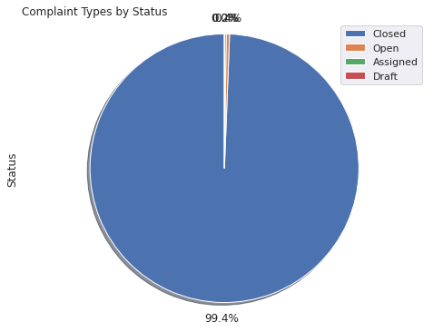

```python
#(df_complaints_by_Month['Status'].value_counts()).plot(kind='pie')

(df_complaints_by_Month['Status'].value_counts()).plot(kind='pie',
                        figsize =(8,6),
                        autopct='%1.1f%%',
                        startangle=90,
                        shadow=True,
                       labels=None,
                       pctdistance=1.12)

plt.title('Complaint Types by Status',loc='left')

plt.axis('equal')
plt.legend(labels=(df_complaints_by_Month['Status'].value_counts()).index, loc='upper right')
plt.show()
```

## Observations:

```
Majority of the Complaint/Requests are already closed
```

```python
df_month_1= df_complaints_by_Month.groupby(['Request_Created_Month','Complaint Type'])[['Unique Key']].count().unstack().fillna(0)
df_month_1.head()

df_month_1.columns = df_month_1.columns.droplevel()

df_month_1.reset_index(inplace=True)

df_month_1

#Complaint Types by month

from sorted_months_weekdays import *
from sort_dataframeby_monthorweek import *

df_month_1=Sort_Dataframeby_Month(df=df_month_1,monthcolumnname='Request_Created_Month')
df_month_1.head()

df_month_1.plot(kind='bar', x='Request_Created_Month', stacked=True, figsize=(16,5),colormap='tab20b')
plt.legend(loc='upper center', bbox_to_anchor=(0.5, 1.45),
          fancybox=True, shadow=True, ncol=7)
plt.title('Customer complaints by Month & Type')
plt.ylabel('Requests/Complaints Count')
plt.show()
```

[output not shown]

```python
df_month= df_complaints_by_Month.groupby(['Request_Created_Month','Complaint Type'])[['Unique Key']].count().reset_index()
df_month.head()

# sorting the monthly_tickets_df in calendar months order
from sorted_months_weekdays import *
from sort_dataframeby_monthorweek import *

df_month=Sort_Dataframeby_Month(df=df_month,monthcolumnname='Request_Created_Month')
df_month.head()

import plotly.express as px

fig = px.bar(df_month, x="Request_Created_Month", y="Unique Key",color='Complaint Type',
              title='Customer complaints by Month & Type')
fig.update_xaxes(tickangle = 0)
fig.show()
```

[output not shown]

## Observations:

# Plotting the Complaint types in a map

```python
df_loc=csr_df[['Unique Key','Complaint Type','City','Location','Longitude','Latitude']]
df_loc.head()
df_loc.dropna(inplace=True) # dropping all nan values
df_loc.isnull().sum()
```

[output not shown]

```python
df_loc.shape
```

[output not shown]

```python
#selecting a 50% sample of the data
df_loc_sample=df_loc.sample(frac=0.5, replace=False, random_state=1)
```

```python
df_loc_sample.shape
```

[output not shown]

```python
#limit = 100
#df_incidents = df_loc.iloc[0:limit, :]
df_incidents = df_loc_sample
```

```python
df_incidents.shape
```

[output not shown]

```python
#df_incidents.dropna(inplace=True)
```

```python
df_incidents.isnull().sum()
```

[output not shown]

```python
import folium
from folium import plugins

# let's start again with a clean copy of the map of San Francisco
nyc_map=folium.Map(location=[40.730610,-73.935242],zoom_start=7)

# instantiate a mark cluster object for the incidents in the dataframe
incidents = plugins.MarkerCluster().add_to(nyc_map)

# loop through the dataframe and add each data point to the mark cluster
for lat, lng, label, in zip(df_incidents.Latitude, df_incidents.Longitude, df_incidents['Complaint Type']):
    folium.Marker(
        location=[lat, lng],
        icon=None,
        popup=label,
    ).add_to(incidents)

# display map
nyc_map
```

[output not shown]